# LAB 4: CROSS VALIDATION & BOOTSTRAPPING

Anand Jacob Abraham

2026-02-03

# Cross validation

It is a method used to assess out of generalizable performace of the model. Often we do a random train test split to assess the model performance. However, this is not a robust measure as the superior (inferior) performance of the model may be a consequence of the choice of test data set. What if we fit the model to different training sets and then test out on another training set. This is the basic idea behind cross validation. We divide the data into various (say $k$) folds. We will test the model on one of the folds and build model on the others. The overall performance across all $k$ folds is taken as a measure of performance. Let’s first load the required libraries and build a model.

```r
library(ISLR)
library(ggplot2)
library(boot)
data("Auto")
```

## Building candidate models and comparison through a validation set approach

We will use various models to compare performances. Lets split into train and test set respectively.

```r
train = sample(392,196)
attach(Auto)
Auto.tr <- Auto[train,]
lm.fit <- lm(mpg ~ horsepower, data = Auto, subset = train)
summary(lm.fit)
```

```
##
## Call:
## lm(formula = mpg ~ horsepower, data = Auto, subset = train)
##
## Residuals:
##      Min       1Q   Median       3Q      Max
## -13.4313  -3.5043  -0.5918   2.8185  17.0250
##
## Coefficients:
##              Estimate Std. Error t value Pr(>|t|)
## (Intercept) 40.194903   1.037981   38.72   <2e-16 ***
## horsepower  -0.163383   0.009667  -16.90   <2e-16 ***
## ---
## Signif. codes:  0 '***' 0.001 '**' 0.01 '*' 0.05 '.' 0.1 ' ' 1
##
## Residual standard error: 4.791 on 194 degrees of freedom
## Multiple R-squared:  0.5955, Adjusted R-squared:  0.5934
## F-statistic: 285.6 on 1 and 194 DF,  p-value: < 2.2e-16
```

```r
lm.fit2 <- lm(mpg ~ poly(horsepower,2), data = Auto, subset = train)
summary(lm.fit2)
```

```
##
## Call:
## lm(formula = mpg ~ poly(horsepower, 2), data = Auto, subset = train)
##
## Residuals:
##      Min       1Q   Median       3Q      Max
## -14.6219  -2.7437  -0.2672   2.6113  14.7910
##
## Coefficients:
##                       Estimate Std. Error t value Pr(>|t|)
## (Intercept)            23.2652     0.3047  76.364  < 2e-16 ***
## poly(horsepower, 2)1 -119.1268     6.5507 -18.185  < 2e-16 ***
## poly(horsepower, 2)2   49.1896     6.6546   7.392 4.29e-12 ***
## ---
## Signif. codes:  0 '***' 0.001 '**' 0.01 '*' 0.05 '.' 0.1 ' ' 1
##
## Residual standard error: 4.241 on 193 degrees of freedom
## Multiple R-squared:  0.6848, Adjusted R-squared:  0.6815
## F-statistic: 209.6 on 2 and 193 DF,  p-value: < 2.2e-16
```

```r
mean((mpg - predict(lm.fit2,Auto[-train]))^2)
```

```
## [1] 19.08639
```

```r
lm.fit3 <- lm(mpg ~ poly(horsepower,3), data = Auto, subset = train)
summary(lm.fit3)
```

```
##
## Call:
## lm(formula = mpg ~ poly(horsepower, 3), data = Auto, subset = train)
##
## Residuals:
##      Min       1Q   Median       3Q      Max
## -14.6595  -2.5948  -0.1822   2.2928  14.3703
##
## Coefficients:
##                      Estimate Std. Error t value Pr(>|t|)
## (Intercept)            23.291      0.303  76.867  < 2e-16 ***
## poly(horsepower, 3)1 -120.035      6.526 -18.393  < 2e-16 ***
## poly(horsepower, 3)2   49.320      6.612   7.459 2.93e-12 ***
## poly(horsepower, 3)3  -12.587      6.707  -1.877   0.0621 .
## ---
## Signif. codes:  0 '***' 0.001 '**' 0.01 '*' 0.05 '.' 0.1 ' ' 1
##
## Residual standard error: 4.213 on 192 degrees of freedom
## Multiple R-squared:  0.6905, Adjusted R-squared:  0.6856
## F-statistic: 142.8 on 3 and 192 DF,  p-value: < 2.2e-16
```

```r
mean((mpg - predict(lm.fit3,Auto))[-train]^2)
```

```
## [1] 21.06729
```

```r
lm.fit4 <- lm(mpg ~ poly(horsepower,4), data = Auto, subset = train)
summary(lm.fit3)
```

```
##
## Call:
## lm(formula = mpg ~ poly(horsepower, 3), data = Auto, subset = train)
##
## Residuals:
##      Min       1Q   Median       3Q      Max
## -14.6595  -2.5948  -0.1822   2.2928  14.3703
##
## Coefficients:
##                      Estimate Std. Error t value Pr(>|t|)
## (Intercept)            23.291      0.303  76.867  < 2e-16 ***
## poly(horsepower, 3)1 -120.035      6.526 -18.393  < 2e-16 ***
## poly(horsepower, 3)2   49.320      6.612   7.459 2.93e-12 ***
## poly(horsepower, 3)3  -12.587      6.707  -1.877   0.0621 .
## ---
## Signif. codes:  0 '***' 0.001 '**' 0.01 '*' 0.05 '.' 0.1 ' ' 1
##
## Residual standard error: 4.213 on 192 degrees of freedom
## Multiple R-squared:  0.6905, Adjusted R-squared:  0.6856
## F-statistic: 142.8 on 3 and 192 DF,  p-value: < 2.2e-16
```

```r
mean((mpg - predict(lm.fit4,Auto))[-train]^2)
```

```
## [1] 20.9698
```

## Leave one out cross validation

Let’s assess the performance of these models in terms of their average MSE. Let us compare models of polynomial terms upto degree 4. We will do this automatically using a for loop.

```r
cv.error.LOOCV<-rep(0,4)# An array7 of 0 repeated 4 times
cv.error.10fold<-rep(0,4)
for(j  in 1:4){
  model<-glm(mpg~poly(horsepower,j),data=Auto)#As family is not specified, the default Linear model is implemented.
  cv.error.LOOCV[j]<-cv.glm(Auto,model)$delta[1]# Performs leave one outcross validation and returns the average MSE
  cv.error.10fold[j]<-cv.glm(Auto,model,K=10)$delta[1]
}
```

Lets plot these errors.

## K-fold cross validation

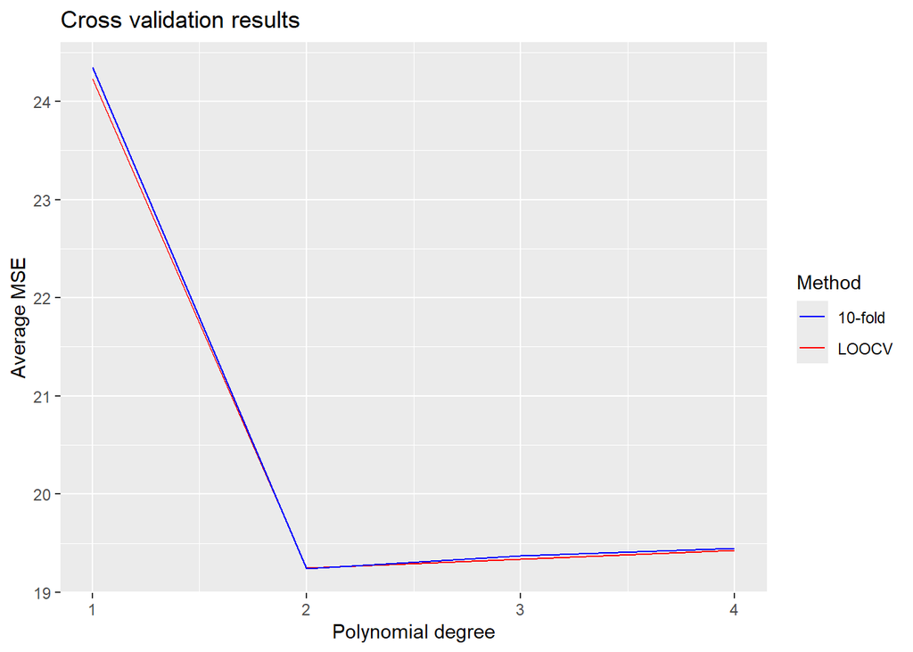

```r
ggplot() +
  # Map a string label to 'color' inside aes()
  geom_line(aes(x = 1:4, y = cv.error.LOOCV, color = "LOOCV")) +
  geom_line(aes(x = 1:4, y = cv.error.10fold, color = "10-fold")) +
  # Manually assign the red and blue colors to those labels
  scale_color_manual(values = c("LOOCV" = "red", "10-fold" = "blue")) +
  labs(
    x = "Polynomial degree",
    y = "Average MSE",
    title = "Cross validation results",
    color = "Method" # Legend title
  )
```

## Cross validation using caret package

We can do cross validation using the caret package also. The main advantage of this is that caret allows you to get error metrics other than the MSE. Rsquares, RMSE, MAE can be computed. Instead of `lm` random forest can also be implmented.

```r
library(caret)
```

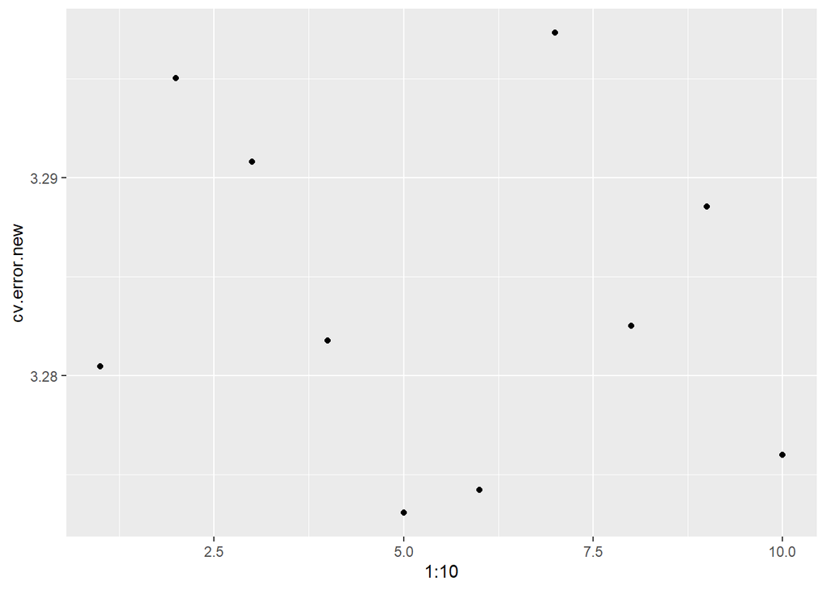

```r
ctrl<- trainControl(method = "cv", number = 10)
form <- as.formula(paste("mpg ~ poly(horsepower,", j, ")"))
cv.error.new<-rep(0,10)
for (j in 1:10){
  model_caret <- train(form,
                       data = Auto,
                       method = "lm",
                       trControl = ctrl)
  cv.error.new[j] <- model_caret$results$MAE#Rsquares, RMSE,MAE can be compared. Instead of lm random forest can also be implmented
}

ggplot()+
  geom_point(aes(x=1:10,y=cv.error.new));
```

# Bootstrapping

```r
data("Portfolio")
#define a function for computing something of interest, in this case alpha
alpha.fn = function(data, index){
  X = data$X[index]
  Y = data$Y[index]
  return ((var(Y) - cov(X,Y))/(var(X) + var(Y) - 2*cov(X,Y)))
}
```

Let’s bootstrap by sampling from the 100 observations another 100 with replacement. This would result in multiple copies of the same observation.

```r
library(boot)
boot(Portfolio, alpha.fn, R = 1000)
```

```
##
## ORDINARY NONPARAMETRIC BOOTSTRAP
##
##
## Call:
## boot(data = Portfolio, statistic = alpha.fn, R = 1000)
##
##
## Bootstrap Statistics :
##      original      bias    std. error
## t1* 0.5758321 0.005534111  0.08942474
```

## Model accuracy estimation using bootstrapping

```r
boot.fn = function(data, index){
    lm.fit <- lm(mpg ~ horsepower, data = data, subset = index)
    return (coef(lm.fit))
  }

boot_results<-boot(Auto, boot.fn, R=1000)
boot_results
```

```
##
## ORDINARY NONPARAMETRIC BOOTSTRAP
##
##
## Call:
## boot(data = Auto, statistic = boot.fn, R = 1000)
##
##
## Bootstrap Statistics :
##       original        bias    std. error
## t1* 39.9358610  0.0412360738 0.867544360
## t2* -0.1578447 -0.0004118463 0.007483388
```

Just like in the last code snippet, 1000 bootstrapped samples are created and point estimate from that is drawn.

```r
boot.ci(boot_results, type = "perc",index=1)
```

```
## BOOTSTRAP CONFIDENCE INTERVAL CALCULATIONS
## Based on 1000 bootstrap replicates
##
## CALL :
## boot.ci(boot.out = boot_results, type = "perc", index = 1)
##
## Intervals :
## Level     Percentile
## 95%   (38.30, 41.63 )
## Calculations and Intervals on Original Scale
```

```r
boot.ci(boot_results, type = "perc",index=2)
```

```
## BOOTSTRAP CONFIDENCE INTERVAL CALCULATIONS
## Based on 1000 bootstrap replicates
##
## CALL :
## boot.ci(boot.out = boot_results, type = "perc", index = 2)
##
## Intervals :
## Level     Percentile
## 95%   (-0.1734, -0.1446 )
## Calculations and Intervals on Original Scale
```